# Abigail Kotar

Software. Data. Design.

# Freedom to Make Life Choices Across Continents

Author

Abby Kotar, Lily Watson, Will Sorge

Published

December 6, 2023

# Introduction

In order to produce the various visualizations shown below, we added a package that attached country names to various continents and regions (since the Happiness data set does not do this already). We then filtered the data down to only the “freedom to make life choices” column and used colnames to standardize naming, before plotting the data. The plots themselves required a fair amount of wrangling to aid present-ability and variety. We also observed a major confounder in the form of perceptions of corruption, manifesting both internally (based on survey responses) and externally (based on actual civic effects).

# Methodoloy

We started by checking which years have the greatest number of data points. 2007 on wards contains a majority of data points.

| Year | Count |
| --- | --- |
| 2005 | 27 |
| 2006 | 89 |
| 2007 | 102 |
| 2008 | 110 |
| 2009 | 114 |
| 2010 | 124 |
| 2011 | 146 |
| 2012 | 141 |
| 2013 | 136 |
| 2014 | 144 |
| 2015 | 142 |
| 2016 | 141 |
| 2017 | 147 |
| 2018 | 141 |
| 2019 | 143 |
| 2020 | 116 |
| 2021 | 122 |
| 2022 | 114 |

We first looked at which years have the highest amount of data. We saw that 2007 and later had the greatest number of results and decided to graph every 3 years, to ensure there aren’t as many graphs. Then we sorted continents because we were looking at regional differences between different countries. We did a box-plot to show how the medians changed over time, as well as the ranges of data. We wanted to be able to see outliers as well as the means.

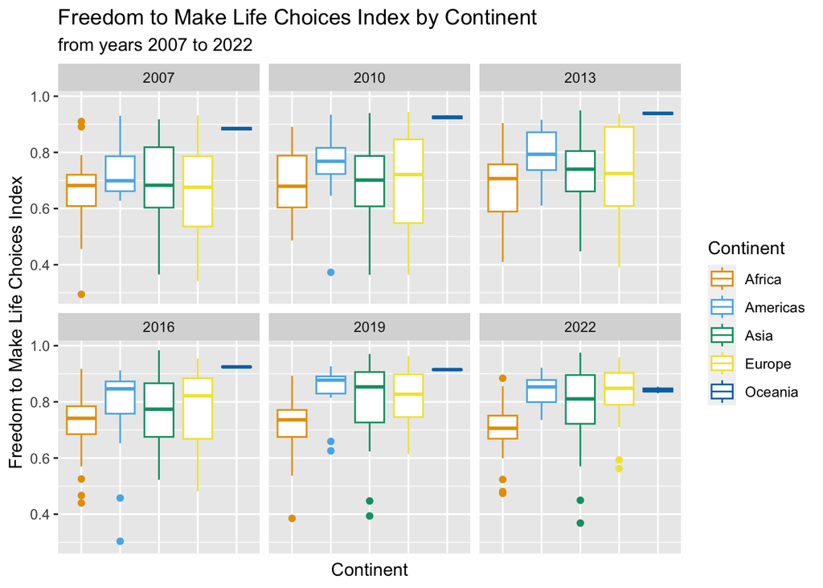

| Continent | Minimum | Maximum | Mean | Standard Deviation |
| --- | --- | --- | --- | --- |
| Africa | 0.260 | 0.968 | 0.692 | 0.118 |
| Americas | 0.281 | 0.957 | 0.792 | 0.109 |
| Asia | 0.315 | 0.985 | 0.746 | 0.145 |
| Europe | 0.258 | 0.971 | 0.763 | 0.152 |
| Oceania | 0.831 | 0.949 | 0.917 | 0.026 |

We then looked at how freedom to make life choices changed from 2007 to 2022 with a scatter plot, colored by regions. We wanted to further break down the changes and be able to see if regions mattered within continents. We also wanted to see if certain countries stayed high or lower and what happened after COVID.

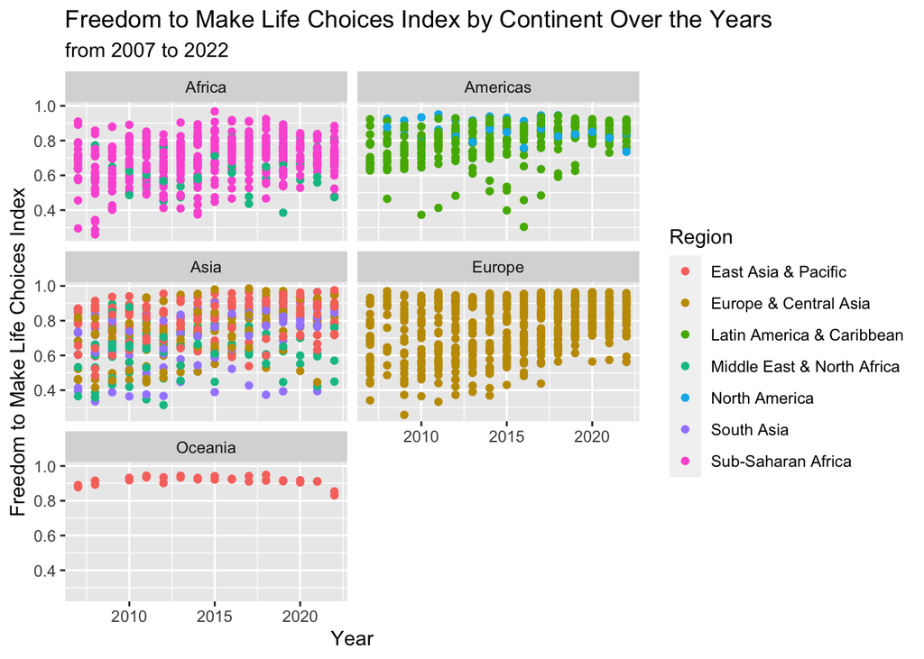

We wanted to also look at the stats by region to see if there was any major difference inside of continents. Sub-Saharan Africa has the lowest mean, while North America has the highest mean. The lowest min is in Europe and Central Asia, as is the highest max. When divided by region, North America has the highest min and smallest standard deviation. This is interesting, as Oceania as a continent has consistently very high ratings but the region of East Asia & Pacific brings down those ratings.

| Region | Mean | Median | Minimum | Maximum | Standard Deviation |
| --- | --- | --- | --- | --- | --- |
| East Asia & Pacific | 0.831 | 0.864 | 0.484 | 0.975 | 0.101 |
| Europe & Central Asia | 0.753 | 0.779 | 0.258 | 0.985 | 0.152 |
| Latin America & Caribbean | 0.783 | 0.806 | 0.281 | 0.942 | 0.110 |
| Middle East & North Africa | 0.700 | 0.700 | 0.315 | 0.962 | 0.145 |
| North America | 0.878 | 0.882 | 0.736 | 0.957 | 0.057 |
| South Asia | 0.698 | 0.741 | 0.335 | 0.906 | 0.163 |
| Sub-Saharan Africa | 0.697 | 0.716 | 0.260 | 0.968 | 0.118 |

We then wanted to look at some confounders for freedom to make life choices which we decided were perceptions of corruption and the life ladder index. Perceptions of corruption was a more external factor while the life ladder index is based on people’s assumptions.

### Perceptions of Corruption Index

We to facet by continent to showcase the differences in results between each continent. Here, we can see that Africa, Americas, and Asia typically have higher perceptions of corruption. All continents, except Oceania, have some countries that interestingly have a higher perception of corruption and a high freedom to make life choices. We set the scales on all graphs to be equal so we could truly see the differences between each continent.

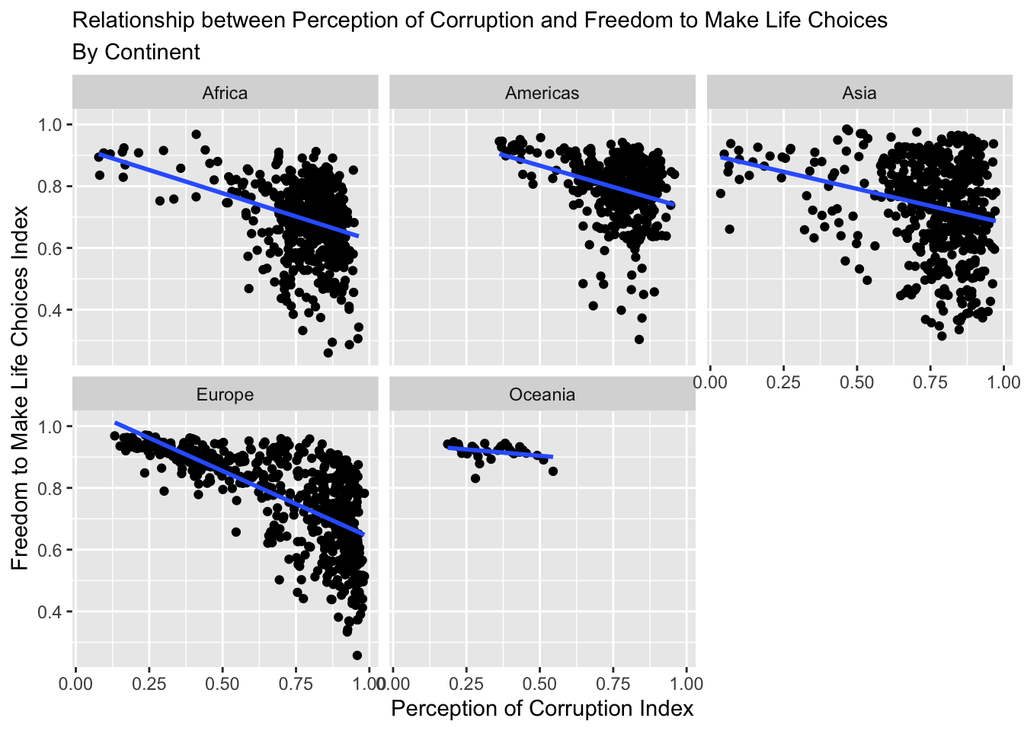

| Continent | Mean | Median | Minimum | Maximum | Standard Deviation |
| --- | --- | --- | --- | --- | --- |
| Africa | 0.783 | 0.813 | 0.078 | 0.964 | 0.132 |
| Americas | 0.765 | 0.794 | 0.362 | 0.959 | 0.115 |
| Asia | 0.752 | 0.792 | 0.035 | 0.973 | 0.171 |
| Europe | 0.717 | 0.823 | 0.132 | 0.983 | 0.241 |
| Oceania | 0.346 | 0.345 | 0.186 | 0.545 | 0.094 |

Looking at the perceptions of corruption, we can see that Africa has the highest mean, and Oceania has the lowest mean. Europe has the largest standard deviation while Oceania has the lowest standard deviation.

### Life Ladder

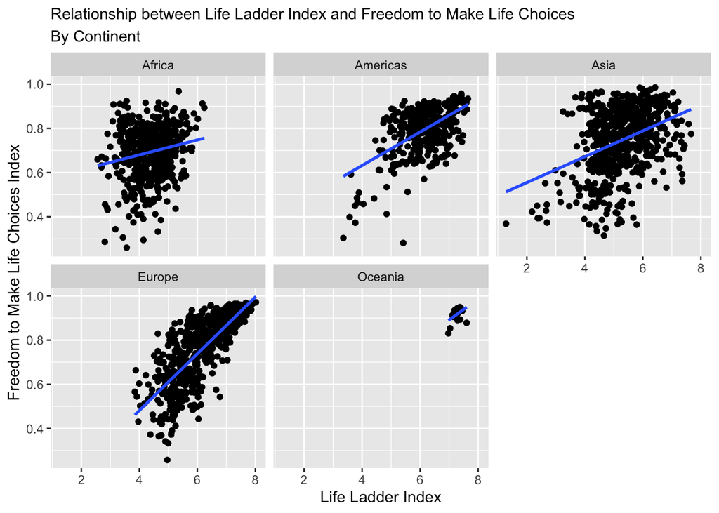

| Continent | Mean | Median | Minimum | Maximum | Standard Deviation |
| --- | --- | --- | --- | --- | --- |
| Africa | 4.375 | 4.396 | 2.560 | 6.241 | 0.656 |
| Americas | 6.113 | 6.136 | 3.352 | 7.650 | 0.780 |
| Asia | 5.275 | 5.241 | 1.281 | 7.662 | 0.937 |
| Europe | 6.194 | 6.151 | 3.844 | 8.019 | 0.928 |
| Oceania | 7.267 | 7.257 | 6.975 | 7.604 | 0.122 |

Africa has the lowest mean, while Oceania has the highest mean. Asia has the largest standard deviation, as shown by its low min and high max. Europe also has a larger standard deviation and has the highest max.

# Results

First, we wanted to examine the proportions of high or low corruption, freedom and life ladder indexes by continent. Knowing each continent has a different number of countries within it, we wanted to look at proportions in order to get a better picture of the distribution of the data. We wanted to look at the relationships between levels of perceptions of corruption, freedom to make life choices, and life ladder. We thought that these might differ per continent based on different cultural values and ideas of what freedom means. When examining these proportions, we were looking for differences between continents to see if there a relationship between continents and different indexes. Based on these proportions, we would further examine the relationships between different continents that we think could explain some of these inequalities.

For perceptions of corruption and freedom to make life choices, we determined high would be above $0.7$, medium would be above $0.5$, and low would be below $0.5$ based on the range of data seen in the graphs. Similarly, for life ladder index, above 7 is high, above 5 is middle, and below 5 is low.

| Continent | Prop. High Freedom Index | Prop. Medium Freedom Index | Prop. Low Freedom Index |
| --- | --- | --- | --- |
| Africa | 0.542 | 0.382 | 0.076 |
| Americas | 0.822 | 0.151 | 0.027 |
| Asia | 0.668 | 0.262 | 0.071 |
| Europe | 0.675 | 0.267 | 0.058 |
| Oceania | 1.000 | 0.000 | 0.000 |

| Continent | Prop. High Life Ladder | Prop. Medium Life Ladder | Prop. Low Life Ladder |
| --- | --- | --- | --- |
| Africa | 0.000 | 0.168 | 0.832 |
| Americas | 0.137 | 0.789 | 0.074 |
| Asia | 0.035 | 0.578 | 0.387 |
| Europe | 0.242 | 0.664 | 0.094 |
| Oceania | 0.969 | 0.031 | 0.000 |

| Continent | Prop. High Perceptions of Corruption | Prop. Medium Perceptions of Corruption | Prop. Low Perceptions of Corruption |
| --- | --- | --- | --- |
| Africa | 0.858 | 0.106 | 0.036 |
| Americas | 0.786 | 0.162 | 0.052 |
| Asia | 0.736 | 0.181 | 0.083 |
| Europe | 0.616 | 0.153 | 0.231 |
| Oceania | 0.000 | 0.062 | 0.938 |

In life ladder, Africa has 0% in the high life ladder section while Oceania has 0% in the low life ladder section. Africa has a majority in the low life ladder section, close to 83% while other Asia, Americas, and Europe have a majority in the middle.

### Hypothesis

#### Freedom to Make Life Choices in Europe vs Africa

Null Hypothesis: There is no difference in freedom to make life choices by continent. $H_0: F_E = F_A$ where $F$ is freedom to make life choices

Alternative Hypothesis: There is a difference in freedom to make life choices between Europe and Africa. $H_A: F_E \neq F_A$

#### Perceptions of Corruption in Europe and Asia

One of our key questions was looking at how cultural differences manifest within the data. We believed that Europeans and Asians have different ways they perceive corruption within society due to different histories and cultural values. To examine this further, we created a hypothesis test to look at the differences in perception of corruption.

Null Hypothesis: There is no relationship between perceptions of corruption and continent.

$H_0: C_E = C_A$ where $C$ is perception of corruption.

Alternative Hypothesis: There is a relationship between perceptions of corruption and continent.

$H_A: C_E \neq C_A$

Based on the calculated p value of 0.0068, if our $\alpha = 0.05$, $\alpha >= p$ so we can reject the null hypothesis. Therefore, we can conclude that perceptions of corruption and continent are not independent for Europe and Asia.

#### Perceptions of Corruption by Region in the Americas

When separating the countries into continents, we noticed that North America and South America were grouped together. We wondered if this caused any discrepancy within the results of perceptions of corruption calculated for the Americas. Since the United States and Canada have not been on the receiving end of colonization or coup d’etats recently, we wondered if the mean perceptions of corruption in the Americas did not accurately represent the countries within in. Therefore, we did a hypothesis test to if there is a relationship between region within the Americas and perceptions of corruption.

Null Hypothesis: There is no relationship between region in the Americas and the perceptions of corruption.

$H_0: C_{NA} = C_{LA}$ where $C$ is the perception of corruption by region.

Alternative Hypothesis: There is a relationship between region and the perceptions of corruption.

$H_A: C_{NA} \neq C_{LA}$

Based on our calculated p value of 0.1368 and $\alpha = 0.05$, we cannot reject the null hypothesis since $p >= \alpha$.

#### Life Ladder in Asia vs Europe

Aforementioned, we believed there would be a cultural difference in Europe and Asia. To further examine this, we did another hypothesis test looking at life ladder between Asia and Europe. We wonder if a different input on what happiness is or what satisfaction in life is may contribute to a relationship between continent and life ladder index.

Null Hypothesis: There is no relationship between the median of life ladder between continents. $H_0: L_A = L_E$ where $L$ is life ladder index.

Alternative Hypothesis: There is a relationship between the median life ladder index and continents. $H_A: L_A \neq L_E$

Based on the p value of 0, we can reject the null hypothesis since $\alpha = 0.05$ and $p < \alpha$. When increasing the number of reps, $p = 0$, so we can reject the null and believe that there is a relationship between life ladder index and continent.

#### Single Regression: Freedom to Make Life Choices and Continents

We choose Africa as our baseline to do the regression since it had proportionally the lowest high freedom index and high life ladder. It also had the highest proportion of high perceptions of corruption. We wanted to expand on our hypothesizes by creating a linear regression for freedom to make life choices and continent, as we had seen a relationship between continent and freedom to make life choices in Africa and Europe.

| Variable | Estimate | Standard Error | Statistic | p-value |
| --- | --- | --- | --- | --- |
| (Intercept) | 0.6924929 | 0.0057692 | 120.032969 | 0 |
| continentsAmericas | 0.0995592 | 0.0090793 | 10.965507 | 0 |
| continentsAsia | 0.0538083 | 0.0078790 | 6.829293 | 0 |
| continentsEurope | 0.0728654 | 0.0079742 | 9.137682 | 0 |
| continentsOceania | 0.2241930 | 0.0243701 | 9.199499 | 0 |

Based on these results, we found statistically significant relationships between continent and freedom to make life choices, for all continents. The results suggest that, on average, we expect freedom to make life choices to be 0.1 units higher in the Americas, 0.05 units higher in Asia, 0.07 units higher in Europe, and 0.2 units higher in Oceania, all relative to Africa.

#### Multiple Regression: Confounders with Freedom to Make Life Choices

To dive deeper into our confounders, perceptions of corruption and life ladder, we did a multiple regression with freedom to make life choices, continent, perceptions of corruption, and life ladder.

| Variable | Estimate | Standard Error | Statistic | p-value |
| --- | --- | --- | --- | --- |
| (Intercept) | 0.6054944 | 0.0228808 | 26.4630125 | 0.0000000 |
| continentsAmericas | -0.0066683 | 0.0093749 | -0.7112849 | 0.4769887 |
| continentsAsia | -0.0125875 | 0.0072055 | -1.7469207 | 0.0808010 |
| continentsEurope | -0.0527872 | 0.0086773 | -6.0833794 | 0.0000000 |
| continentsOceania | -0.0447860 | 0.0219676 | -2.0387297 | 0.0416052 |
| perceptions_of_corruption | -0.2215258 | 0.0153521 | -14.4296320 | 0.0000000 |
| life_ladder | 0.0595329 | 0.0032667 | 18.2243850 | 0.0000000 |

Next, we created a multiple regression model that included our confounding variables: perceptions of corruption and life ladder score. We saw statistically significant relationships for Europe and Oceania, but not the Americas and Asia. On average, we expect the freedom to make life choices in Europe to be 0.05 units lower than in Africa when keeping perceptions of corruption and life ladder score constant. On average, we expect the freedom to make life choices in Oceania to be 0.04 units lower than in Africa when keeping perceptions of corruption and life ladder score constant.

# Discussion

Through this project, we wanted to observe how the freedom to make life choices is perceived across different countries, continents, and regions. Stratifying our analysis by geographical groups allowed us to postulate whether regional cultural norms and historical events relevant to certain geographies may have influenced outcomes. Our boxplot visualizations allowed us to easily compare the median perception of freedom across different continents. Furthermore, the hypothesis tests that we ran allowed us to directly compare multiple continents and regions on selected indices. The tests were: freedom to make life choices in Europe versus Africa, perceptions of corruption in Europe versus Asia, perceptions of corruption by region in the Americas, and life ladder in Europe versus Asia. These were chosen primarily based on visual inferences from our graphs and calculated summary statistics and proportions.

We chose to use Africa as our baseline based on our calculated proportions, which showed that Africa had the lowest proportion of high freedom to make life choices and high life ladder and the highest proportion of high perceptions of corruption. This seemed to generally be the continent with the worst scores. Our simple regression model analysis supports our primary assertion that there is a relationship between continent and freedom to make life choices. However, our multiple regression model indicates that there is a more nuanced relationship between these variables as the inclusion of potential confounders, perception of corruption and life ladder score, changed the relationship seen. This model showed that when holding the perception of corruption and life ladder score constant, the freedom to make life choices index decreased, on average, in Europe and Oceania compared to Africa.

When looking at the relationship between the perception of corruption and freedom to make life choices by continent, we noticed negative linear trends; as perception of corruption increased, freedom to make life choices generally decreased. In the Americas, Asia, and Europe, there are many data points indicating high perceptions of corruption correlated with high freedom to make life choices. Adding a third variable, time, to these graphs may broaden understanding of historical trends. However, we were primarily interested in investigating the relationship between the two variables, so we chose not to filter by year. Future research could expand on this analysis by incorporating time. The summary statistics stratified by continent show interesting trends. Europe has the largest standard deviation. A limitation of our research is that we cannot separate Eastern and Western European countries in our analysis. Given the historically different political structures of these nations, combining them into a single group may cloud underlying trends and may explain the wide range of perceptions of corruption scores calculated for the continent. Both Africa and Asia have incredibly low minimum scores, which we found surprising based on the freedom index scores for these continents. Further research could explore which specific countries might be outliers accounting for those data.

Overall, while our analysis yielded interesting results, there were a few things that we could have approached differently. To begin, the data set we used did not have data for every country in every continent for every year, which poses a limitation to the scope of our study. For example, some countries only had data from 2008-2015, which rendered us unable to observe their long-term changes. Other countries were not in the data set at all. In Oceania, there were only two countries, Australia and New Zealand. This small sample size inclusive of only Western-aligned nations does not provide any information about other islands in Oceania. This raised Oceania’s rating higher when not all countries within Oceania are thriving. In addition, when grouping with the country code package, we did not get much information on what countries belong to each continent. For countries like Russia, it could be classified as Europe or Asia. The World Happiness Index does not explain exactly how they collect the data, so details such as whether the participants were surveyed in their native language, how interviewees and surveyors were selected, and whether participants were given clarifying support in answering questions. A random sample conducted in the native language by surveyors highly trained to expertly collect data would be most accurate, as opposed to a convenience sample. Furthermore, more thorough surveys that assessed for other confounders, such as inequality and unemployment, would overcome the limitation of this survey which only includes six factors to explain life evaluations.

Considering our hypotheses, we rejected the null in favor of the alternative for a few. We found an independent relationship between continent and perceptions of corruption in Asia and Europe. We wanted to examine if differences in cultural values by geographical region might explain different views of corruption. Then, we looked at the life ladder difference between Europe and Asia, and rejected the null hypothesis that there is no relationship between continent and life ladder rating. We wondered if cultural differences might explain some of these differences. While corruption may seem more universal, life ladder is more subjective and seems to change by continent. We could not reject the null hypothesis that Latin America and North America have no differences in perceptions of corruption. This was surprising, as we believed that Latin America and the Caribbean might rate their corruption higher, due to past colonization, instability in the region, and US-sponsored coup d’etats. However, it seems like North American countries believe they have similar levels of corruption. We also examined whether Europe and Africa had a difference in freedom to make life choices. We could reject the null hypothesis that there is no relationship between continent and freedom to make life choices. Aforementioned, the colonization of Africa could drastically affect this rating. For these hypotheses, we did not sort by time at all, as time was not a variable we were examining. However, if we were to dive more into specific examples we could look at change over time or check dependence relationships with time and the perceptions of corruption or life ladder indices.

If we could redo our analysis, we would ideally collect our own data by randomly sampling individuals from each country. While this would be time-consuming and outside the scope of our project, it would allow us to collect more reliable and relevant data. In addition, if we had chosen a research question centered on a more specific geographical region, we could have dived deeper into specific countries or continents and perhaps may have found more concrete results. If we instead examined outcomes after a specific historical event that occurred during the study period, we could potentially see very interesting results about how political and social turmoil may affect different countries. We were not able to stratify by time, which could have been another test. Exploring this additional variable in the context of the variables we examined may have strengthened the scope of our analysis and fostered deeper insights into our discussion.

Overall, this study shed light on some of the geographical variations in societal perceptions of social rankings. It suggests the importance of expanded accurate data collection to understand the impacts of major political and social events on public freedom to make life choices.

## Questions or comments? **Get in touch:**

- abbyrosekotar@gmail.com
- linkedin.com/in/abigail-kotar/
- © Abigail Kotar. All rights reserved.
- Design: [HTML5 UP](http://html5up.net)